# DATA3888 Assignment 1

490407806

2022-03-14

### 1 Brain-box

In this section, an analysis of 31 .wav files was conducted. These .wav files were created by a Physics instructor Louis, with the file names corresponding to the eye movements in each. A streaming classifier was created and tested on the data. Discussion of these results was then completed.

The necessary libraries were imported as the first step.

```r
library(tidyverse)
library(tuneR)
library(devtools)
library(ggplot2)
library(tsfeatures)
library(stringdist)
```

From here, short, medium and long files were loaded. These .wav files were read using the `tuneR` package, and each file was plotted. At this stage, labelling errors were discovered e.g. although RRL_L1.wav indicates RRL eye movements, visual inspection of the plot showed that the true label was LLR, as seen below. The following files were affected.

- Short .wav files: RLR_L3, RRL_L1, RRL_L2, RRL_L3, RRR_L1, RRR_L2, RRR_L3
- All Medium .wav files
- All Long .wav files

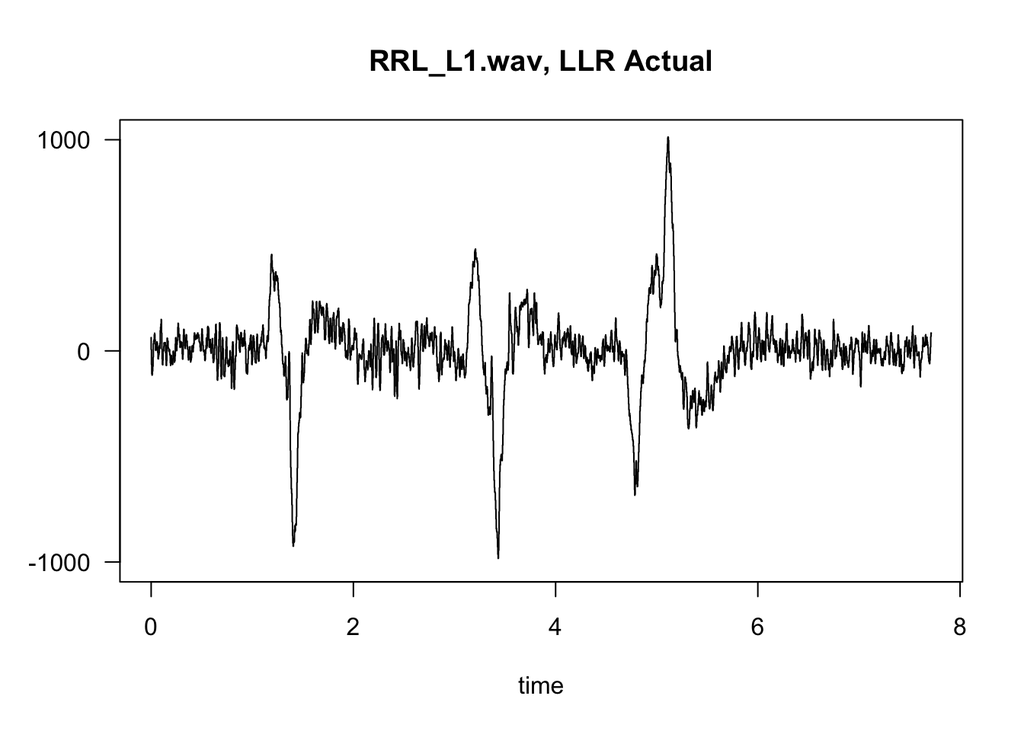

```r
# loading file names
dir_short = '../data/Spiker_box_Louis/Short'
all_files_short <- list.files(dir_short)

dir_medium = '../data/Spiker_box_Louis/Medium'
all_files_medium <- list.files(dir_medium)

dir_long = '../data/Spiker_box_Louis/Long'
all_files_long <- list.files(dir_long)

# reading wave files using tuneR
wave_file_short <- list()
for (i in all_files_short) {
wave_file_short[[i]] <- readWave(file.path(dir_short, i))
}

wave_file_medium <- list()
for (i in all_files_medium) {
wave_file_medium[[i]] <- readWave(file.path(dir_medium, i))
}

wave_file_long <- list()
for (i in all_files_long) {
wave_file_long[[i]] <- readWave(file.path(dir_long, i))
}

# repeated for short, medium, long files, visual check done, all medium and long files are labelled incorrectly

#for (i in 1:length(wave_file_short)){
#  timeSeq <- seq_len(length(wave_file_short[[i]]))/wave_file_short[[i]]@samp.rate
#  plot <- ggplot() + geom_line(aes(x=timeSeq, y=wave_file_short[[i]]@left)) + ggtitle(all_files_short[i])
#  print(plot)
#}

plot(wave_file_short[[19]], main = "RRL_L1.wav, LLR Actual")
```

Given that the sample size was quite small, no programmatic solution was developed to identify mislabeled data. Visual inspection was completely quickly and without error. From here, two lists were created, one holding all wave files, and the second holding target labels as strings extracted from the file names.

Since some file names were mislabeled, these were corrected and added to the target label list by swapping “L” to “R” and vice versa.

```r
# list of all wave files read by tuneR
all_wave_files <- c(wave_file_short, wave_file_medium, wave_file_long)

# identifying file names that were mislabeled
all_change <- c(all_files_short[18:24], all_files_medium, all_files_long)

# list of all target labels
all_target_labels <- c()

# adding originally correct labels to target label list
for (i in 1:17) {
  all_target_labels <- append(all_target_labels, strsplit(all_files_short[i], "_")[[1]][1])
}

# correct labels and adding to target label list
for (i in 1:length(all_change)) {
  char_file_name <- as.vector(strsplit(all_change[i], "")[[1]])
  corrected_name <- ''
  for (ch in char_file_name) {
    if (ch == "_") {
      break
    }
    if (ch == "L") {
      corrected_name <- paste(corrected_name, "R")
    } else {
      corrected_name <- paste(corrected_name, "L")
    }
  }
  all_target_labels <- append(all_target_labels, gsub(" ", "", corrected_name))
}
```

##### 1 [a] Estimate the accuracy of your classifier. Is your value reasonable?

A streaming classifier was then created to identify eye movements in real time. The mechanics of this classifier are as follows:

In essence, a window of values was isolated. The number of zero crossings was calculated for this window, and if it was less than a threshold value, the algorithm identified that an event occurred in this window. Classification was then completed as detailed below. From here, the window was moved across by the increment and so on until the end of the .wav file. The combination of individual classifications were combined to become the final string prediction.

*Event Classification*

One significant issue with the above method was that multiple windows would give a prediction for the same event given that the increment was less than the window. Since an arbitrary window could contain only part of an event, errors were made. Increasing the increment size was unfeasible since it reduced the granularity of the classifier and introduced missed events.

As a result, we define an event subsequence as consecutive event predictions, enclosed on both sides by a lack of events. Where NE represents No Event, given the following progression: NE, NE, L, L, R, NE, the event subsequence would be LLR. For each event subsequence, the final prediction for a single eye movement is defined as the majority class (L, in the example).

In doing so, it was important that the increments were small, and the threshold was relatively large. The intuition was that by having multiple predictions for the same eye movement event, classification errors from a window only partially containing the event would be mitigated against.

```r
# simple decision rule
LR_detection = function(seq) {
  maxval = which.max(seq)
  minval = which.min(seq)
  movement = ifelse(maxval < minval,  "L", "R")
  return(movement)
}

streaming_classifier = function(wave_file,
                                window_size = wave_file@samp.rate,
                                increment = window_size/10) {
  Y = wave_file@left
  xtime = seq_len(length(wave_file@left))/wave_file@samp.rate
  predicted_labels = c()
  lower_interval = 1
  max_time = max(xtime)*window_size

  sequence <- FALSE
  # keeping count of the number of L and R in a given event subsequence, curr_sequence[1] being L, and [2] being R
  curr_sequence <- c(0, 0)
  while(max_time > lower_interval + window_size) {

    upper_interval = lower_interval + window_size
    interval = Y[lower_interval:upper_interval]

    # zero crossings to identify if an event existed within a window
    zero_crossings = sum(interval[1:(length(interval) - 1)] * interval[2:(length(interval))] <= 0)

    if (zero_crossings <= 70) {
      predicted = LR_detection(interval)
      if (predicted == "L") {
        curr_sequence <- c(curr_sequence[1] + 1, curr_sequence[2])
      } else {
        curr_sequence <- c(curr_sequence[1], curr_sequence[2]+1)
      }
      sequence <- TRUE

    } else {
      if (sequence == TRUE) {
        # determining majority class
        if (curr_sequence[1] >= curr_sequence[2]) {
          predicted_labels = c(predicted_labels, "L")
        } else {
          predicted_labels = c(predicted_labels, "R")
        }
      }
      sequence <- FALSE
      curr_sequence <- c(0,0)
    }

    lower_interval = lower_interval + increment
  } ## end while

  return(paste(predicted_labels, collapse=''))
}## end function
```

Having created the streaming classifier, predicted labels were found for all test .wav files, and stored in a list. A similarity score was then determined for each predicted label vs target label, and the overall accuracy was found by averaging the similarity scores of each .wav file.

The similarity score was based off the Levenshtein distance, which determined the minimum number of insertions, deletions and substitutions needed to transform one string into the other. For the purposes of this classifier, raw Levenshtein distance scores were difficult to interpret, especially since longer .wav files were likely to contain more errors. Alternative metrics included the Damerau–Levenshtein distance, although this was not chosen since it allowed transpositions. This was not appropriate since eye movements happened sequentially, and so two incorrect predictions for two separate events could not reasonably be swapped.

The similarity score is thus defined as:

$$\text{Similarity Measure} = 1-{\text{Levenshtein Distance(A, B)} \over \text{max}(|A|, |B|)}
\\ \text{where A is the target string, and B is the predicted value}$$

In this case, the Levenshtein distance over the longer of the two strings detailed how incorrect the prediction was. Assuming that a score of 1 indicates a perfect prediction thus gives the formula above.

```r
# applying the streaming classifier to each .wav file
all_predicted_labels <- c()
for (i in 1:length(all_wave_files)) {
  all_predicted_labels <- c(all_predicted_labels, streaming_classifier(all_wave_files[[i]]))
}

# calculating similarity measure
prediction_accuracies <- c()
for (i in 1:length(all_predicted_labels)) {
  lv_distance <- stringdist(all_predicted_labels[i], all_target_labels[i], method="lv")
  len_predicted <- length(as.vector(strsplit(all_predicted_labels[i], "")[[1]]))
  len_target <- length(as.vector(strsplit(all_target_labels[i], "")[[1]]))
  longest_string <- max(c(len_predicted, len_target))
  prediction_accuracies <- append(prediction_accuracies, 1-lv_distance/longest_string)
}

#calculating overall accuracy
overall_accuracy <- mean(prediction_accuracies)
print(paste("Overall Accuracy:", round(overall_accuracy,2)))
```

```
## [1] "Overall Accuracy: 0.91"
```

The number above is the accuracy of the streaming classifier in correctly predicting results. It can be concluded that the classifier was effective on a broad level. It is also a reasonable score. A visual comparison of target strings versus predicted strings shows that predictions contained only minor errors. Furthermore, given that eye movement events followed such a distinct pattern, these results are not infeasible.

##### 1 [b] Does the length of the sequence impact on the classification accuracy?

The length of the sequence does impact the classification accuracy. This can be seen in the following boxplot, where the average accuracies decline as the length of the file increases. It should be noted that although the minimum value of the Short files is lower than that of the Medium and Long files, a single incorrect classification would give that result - LRL vs LLL is $1 - 1/3 = 0.66$ accuracy.

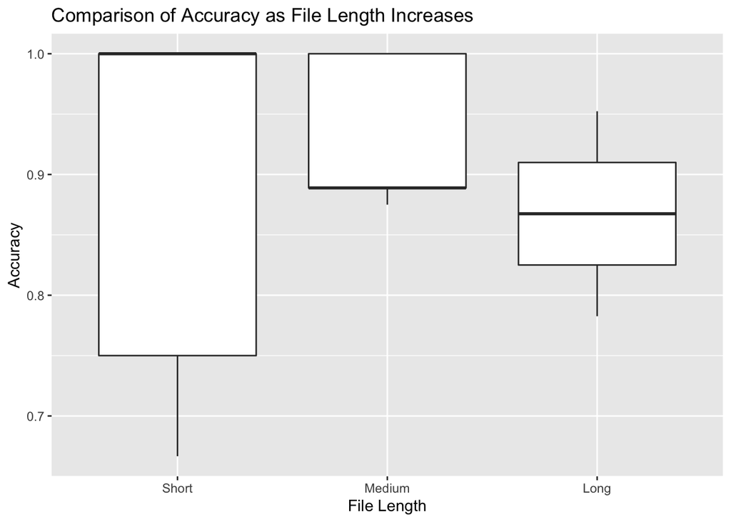

```r
# Creating tibble for visualisation
comparison <- tibble(file_length = "Short", accuracy = prediction_accuracies[1:24])
comparison <- comparison %>% add_row(file_length = "Medium", accuracy =prediction_accuracies[25:29])
comparison <- comparison %>% add_row(file_length = "Long", accuracy =prediction_accuracies[30:31])

file_length_order = c("Short", "Medium", "Long")
comparison <- comparison %>% mutate(file_length = factor(file_length, level = file_length_order))

ggplot(comparison, aes(x=file_length, y=accuracy)) + geom_boxplot() + labs(x="File Length", y="Accuracy", title = "Comparison of Accuracy as File Length Increases")
```

### 2 Pre-validated Model

In this section, an analysis of kidney transplant data was done. The dataset contained the gene expression profiles of 40 blood samples and their respective patient characteristics.

The necessary libraries were imported, and the gene expression data was read. A number of small changes were made to the data, such as tidying the title variable and naming it `Outcome`. Note: this data has already been log2 transformed.

```r
library(GEOquery)
library(R.utils)
library(reshape2)
library(ggplot2)
library(limma)
library(dplyr)
library(DT)
library(e1071)
library(tidyr)
library(ISLR)

# loading of data
load("../data/gse_GSE46474.RData")

# renaming data for easier use
gse <- gse_GSE46474

# isolating the matrix gene expression data
eMat <- exprs(gse)

# tidying the title variable
gse$Outcome <- ifelse(grepl("AR", gse$title), "Rejection", "Stable")

# finding patient data
patientData <- pData(gse)
```

##### 2 [a] Build a classifier using support vector machine (SVM) to predict the outcome of graft survival and generate a prevalidated outcome from the gene expression data.

Given a matrix of gene expression data, the aim was to identify the genes that were differentially expressed between stable and rejection patients. This was done using by fitting a series of linear models using the `limma` package.

Oddly, when filtering for genes with an adjusted p-value of less than 0.05, the logistic model produced at the bottom of this section displayed some odd results i.e. SVM was insignificant. It is assumed that tiny variances may have driven the t-values. The gene expression data was thus filtered by absolute value log fold change - these are the genes which are significantly expressed more either within the Stable or Rejection group.

```r
design <- model.matrix(~Outcome, data = pData(gse))
fit <- lmFit(eMat, design)
fit <- eBayes(fit)

# sorting genes by log FC
tT <- topTable(fit, n = Inf) %>% top_n(abs(logFC), n=50)
```

All 50 genes were taken to build a pre-validated outcome using support vector machine (SVM).

In this stage, the expression matrix features were reduced to the 50 identified. The patients were divided into five folds, with one fold left out. The remaining four folds were used to derive the support vector machine prediction rule. The prediction rule was used to predict the outcome of the test group, and this was repeated for all five folds.

These outcomes were collected into a vector such that a prediction existed for each patient, and the accuracy was calculated with the target outcome vector, which is seen below.

```r
# isolating significant genes and subsetting expression matrix
DE_eMat <- eMat[rownames(tT), ]

# tranposing matrix for use in SVM
X <- as.matrix(t(DE_eMat))
y = gse$Outcome

# creating 5 folds
cvK = 5
cvSets = cvTools::cvFolds(length(y), cvK)

# pre-validated vector
pre_validated <- vector(, length(y))

for (j in 1:cvK) {
    test_id = cvSets$subsets[cvSets$which == j]

    X_test = X[test_id, ]
    X_train = X[-test_id, ]
    y_test = y[test_id]
    y_train = y[-test_id]
    svm_res = e1071::svm(x = X_train, y = as.factor(y_train))
    fit <- predict(svm_res, X_test)

    for (b in 1:length(test_id)) {
      pre_validated[test_id[b]] <- paste0(fit[[b]], "")
    }
}

count = 0
for (i in 1:length(pre_validated)) {
  if (pre_validated[i] == gse$Outcome[i]) {
    count = count + 1
  }
}

accuracy = count/length(pre_validated)
accuracy
```

```
## [1] 0.85
```

##### 2 [b] Use it together with the clinical variables in a logistic regression to build a risk model. Describe your final model for classifying graft survival in different individuals and your estimate of its accuracy.

This pre-validated vector was then combined with clinical features. In terms of the patient dataset, some columns were irrelevant and not of interest, such as the submission date and organism type (which was consistent across all patients, Homo sapiens). The patient data was reduced to the following characteristics:

- Age
- Sex
- Race
- SVM Prediction
- Actual Result

The structure of this data is seen below:

```r
patientData <- pData(gse)

relevant_features = c("characteristics_ch1",
                      "characteristics_ch1.1",
                      "characteristics_ch1.2")
patientData <- patientData[, relevant_features]

# adding SVM prediction to patient data
patientData$SVM_Prediction <- pre_validated
patientData$Actual <- gse$Outcome

# renaming columns
patientData <- patientData %>%
  rename(
    Age = characteristics_ch1,
    Sex = characteristics_ch1.1,
    Race = characteristics_ch1.2
  )

# fixing naming issues
patientData <- patientData %>% separate(Age, c("remove", "Age"), ": ")
patientData <- patientData %>% separate(Sex, c("remove", "Sex"), ": ")
patientData <- patientData %>% separate(Race, c("remove", "Race"), ": ")
patientData <- patientData[, -which(names(patientData) %in% c("remove"))]

# correcting column types
patientData <- patientData %>%
  mutate(
    Age = as.numeric(Age),
    Race = factor(Race),
    Sex = factor(Sex),
    SVM_Prediction = factor(SVM_Prediction),
    Actual = factor(Actual)
  )


kable(head(patientData))
```

|  | Age | Race | Sex | SVM_Prediction | Actual |
| --- | --- | --- | --- | --- | --- |
| GSM1130812 | 55.7 | Caucasian | M | Stable | Rejection |
| GSM1130813 | 50.3 | Caucasian | M | Stable | Stable |
| GSM1130814 | 52.6 | Caucasian | F | Rejection | Rejection |
| GSM1130815 | 44.8 | Caucasian | F | Stable | Stable |
| GSM1130816 | 38.8 | Asian Indian | F | Rejection | Rejection |
| GSM1130817 | 51.1 | Caucasian | M | Stable | Stable |

At this point, a logistic regression model was fitted. Using backwards AIC model selection gives the following model:

```r
model.full = glm(Actual ~ ., data = patientData, family = binomial)
model.aic = step(model.full, direction = "backward", trace = FALSE)
```

$$E(\hat{outcome}) = -2.833 + 4.679(\text{SVM Prediction})$$

Despite this, it seemed more reasonable to provide a model with clinical variables included. As a result, a new logistic regression model was fitted with Age and Sex as well. Race was excluded as it had little bearing on the final result.

By analysing the coefficients below, it can be seen that the SVM prediction was the most significant factor by far with a p-value well below 0.05.

```r
glm.fit <- glm(Actual ~ Age + Sex + SVM_Prediction, data = patientData, family = binomial)
kable(summary(glm.fit)$coefficients)
```

|  | Estimate | Std. Error | z value | Pr(>\|z\|) |
| --- | --- | --- | --- | --- |
| (Intercept) | -3.4982435 | 2.4367679 | -1.4356080 | 0.1511139 |
| Age | 0.0301438 | 0.0429552 | 0.7017503 | 0.4828349 |
| SexM | 0.4187023 | 0.9962365 | 0.4202840 | 0.6742780 |
| SVM_PredictionStable | 3.5756295 | 0.9550330 | 3.7439854 | 0.0001811 |

```r
# 5 fold cross validation, calculating accuracy
K = 5
cvSets = cvTools::cvFolds(nrow(patientData), K)

X <- patientData
cv_acc <- vector(, length(y))

for (j in 1:K) {
    test_id = cvSets$subsets[cvSets$which == j]
    test = X[test_id, ]
    train = X[-test_id, ]
    glm.fit <- glm(Actual ~ Age + Sex + SVM_Prediction, data = train, family = binomial)
    predictions <- predict(glm.fit, test, type="response")

    for (b in 1:length(test_id)) {
      cv_acc[test_id[b]] <- ifelse(predictions[[b]] > 0.5, "Stable", "Rejection")
    }
}

count = 0
for (i in 1:length(cv_acc)) {
  if (cv_acc[i] == gse$Outcome[i]) {
    count = count + 1
  }
}

accuracy = count/length(cv_acc)
```

With 5 fold cross validation, the accuracy of this model was: 0.9.

##### 2 [c] What is the final prediction based on your final model for a 70-year-old male whose transcriptomics profile is predicted to have a favourable survival outcome?

The final prediction for a 70-year-old male with a transcriptomics profile predicting a favourable survival outcome is: Stable.

```r
glm.fit <- glm(Actual ~ Age + Sex + SVM_Prediction, data = patientData, family = binomial)

patientData <- patientData %>% add_row(Age = 70, Race = NA, Sex = "M", SVM_Prediction = "Stable")
final_pred <- predict(glm.fit, patientData[nrow(patientData), ], type="response")
print(ifelse(final_pred[[1]] > 0.5, "Stable", "Rejection"))
```

```
## [1] "Stable"
```

### 3 Blood vs Biopsy Biomarker

In this section, a comparison was made between a predictive model based on a peripheral blood gene expression dataset, and another predictive model based on kidney biopsy gene expressions.

The necessary libraries were imported, and both datasets were read in. The kidney biopsy data was also normalised.

```r
library(GEOquery)
library(R.utils)
library(reshape2)
library(ggplot2)
library(limma)
library(dplyr)
library(DT)
library(tidyr)
library(preprocessCore)
library(randomForest)

load("../data/gse_GSE138043.RData")
gse_biopsy <- gse_GSE138043

load("../data/gse_GSE46474.RData")
gse_blood <- gse_GSE46474

exprs(gse_biopsy) <- normalize.quantiles(exprs(gse_biopsy))
```

##### 3 [a] Select the top 50 most variable genes in each of the dataset GSE138043 and GSE46474. Combined the two sets of genes and how many genes are in the union of these two list.

The process for this is similar to that in Section 2. The expression datasets were sorted by log fold change and the top 50 were taken. A union of these two lists of genes with the most variability yielded 81 genes (granted some in the blood dataset were not labelled).

```r
# BLOOD
gse_blood$Outcome <- ifelse(grepl("AR", gse_blood$title), 0, 1)
design <- model.matrix(~Outcome, data = pData(gse_blood))
blood_fit <- lmFit(exprs(gse_blood), design)
blood_fit <- eBayes(blood_fit)

# sorting genes by log FC
blood_tT <- topTable(blood_fit, genelist=fData(gse_blood)[,"Gene Symbol"], n = Inf) %>% top_n(abs(logFC), n=50)

# BIOPSY
gse_biopsy$Outcome <- ifelse(grepl("non-AR", gse_biopsy$characteristics_ch1), 1, 0)
design <- model.matrix(~Outcome, data = pData(gse_biopsy))
biopsy_fit <- lmFit(exprs(gse_biopsy), design)
biopsy_fit <- eBayes(biopsy_fit)


gene_name_list <- c()
for (i in 1:length(fData(gse_biopsy)[,"gene_assignment"])){
  gene_name_list <- append(gene_name_list, strsplit(fData(gse_biopsy)[,"gene_assignment"][i], " // ")[[1]][2])
}

# sorting genes by log FC
biopsy_tT <- topTable(biopsy_fit, genelist=gene_name_list, n = Inf) %>% top_n(abs(logFC), n=50)

combination <- union(biopsy_tT[, 1], blood_tT[, 1])
#combination[combination != ""]
length(combination[combination != ""])
```

```
## [1] 81
```

##### 3 [b] Build two classifier using randomForest to predict the outcome of graft survival using the genes selected in part (a).

##### 3 [c] Preform repeated 5-fold cross validation for each of the data and calculate the accuracy. What is the average accuracy for blood vs biopsy biomarker model?

In this section, two **randomForest** classifiers were constructed. The first created used the biopsy data, where a 25 repeated 5 fold cross validation was completed. The accuracy of this model is seen below.

```r
biopsy_eMat <- exprs(gse_biopsy)[rownames(biopsy_tT), ]

# tranposing matrix for use in SVM
X <- data.frame(t(biopsy_eMat))
X['Outcome'] <- factor(gse_biopsy$Outcome)

cvK = 5  # define the number of CV folds
cv_acc_biopsy_25times <- vector(, 25)

for (i in 1:25) {

  # permute all the data, into 5 folds
  cvSets = cvTools::cvFolds(nrow(X), cvK)
  cv_acc_biopsy5 <- vector(, 5)

  for (j in 1:cvK) {
    test_id = cvSets$subsets[cvSets$which == j]
    X_test = X[test_id, ]
    X_train = X[-test_id, ]

    model_rf = randomForest(X_train[, -length(X_train)], X_train[, length(X_train)])
    fit_rf = predict(model_rf, newdata = X_test)
    comparisons <- vector(, length(fit_rf))

    for (b in 1:length(fit_rf)) {
      comparisons[b] <- as.numeric(fit_rf[b])
    }
    cv_acc_biopsy5[j] <- mean(comparisons == as.numeric(X_test[, length(X_test)]))
  }
  cv_acc_biopsy_25times[i] <- mean(cv_acc_biopsy5)
}

mean(cv_acc_biopsy_25times)
```

```
## [1] 0.7853091
```

The second created used blood gene expression data, where another 25 repeated 5 fold cross validation was completed. The accuracy of this model is again seen below.

```r
blood_eMat <- exprs(gse_blood)[rownames(blood_tT), ]

# tranposing matrix for use in SVM
X <- data.frame(t(blood_eMat))
X['Outcome'] <- factor(gse_blood$Outcome)

cvK = 5  # define the number of CV folds
cv_acc_blood_25times <- vector(, 25)

for (i in 1:25) {

  # permute all the data, into 5 folds
  cvSets = cvTools::cvFolds(nrow(X), cvK)
  cv_acc_blood5 <- vector(, 5)

  for (j in 1:cvK) {
    test_id = cvSets$subsets[cvSets$which == j]
    X_test = X[test_id, ]
    X_train = X[-test_id, ]

    model_rf = randomForest(X_train[, -length(X_train)], X_train[, length(X_train)])
    fit_rf = predict(model_rf, newdata = X_test)
    comparisons <- vector(, length(fit_rf))

    for (b in 1:length(fit_rf)) {
      comparisons[b] <- as.numeric(fit_rf[b])
    }
    cv_acc_blood5[j] <- mean(comparisons == as.numeric(X_test[, length(X_test)]))
  }
  cv_acc_blood_25times[i] <- mean(cv_acc_blood5)
}

mean(cv_acc_blood_25times)
```

```
## [1] 0.852
```

##### 3 [d] Select an appropriate graphic to communicate the difference between these two classification accuracy.

To compare the differences between these two classification accuracy’s, a boxplot was created below.

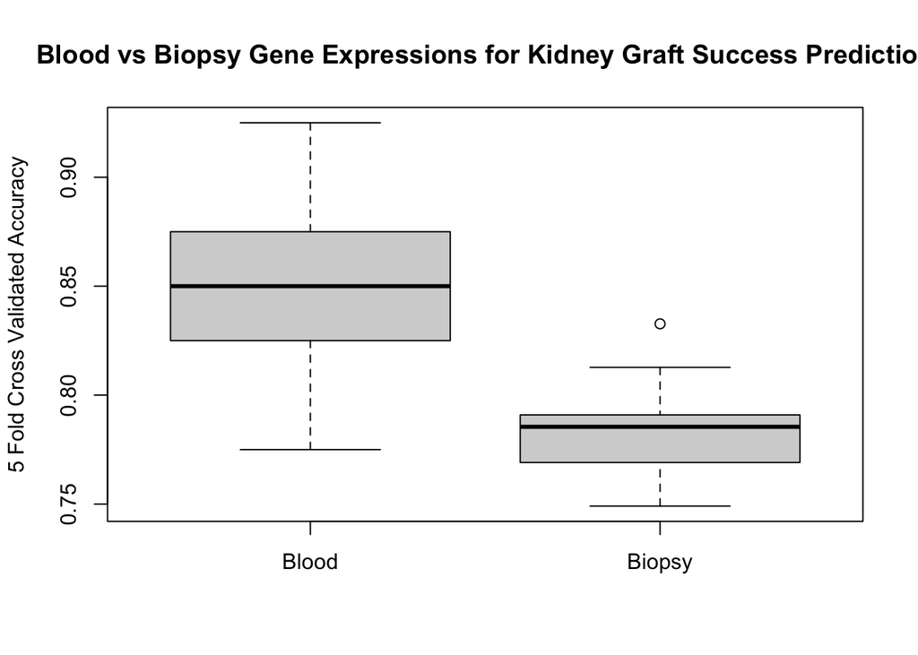

```r
boxplot(cv_acc_blood_25times,
        cv_acc_biopsy_25times,
        main = "Blood vs Biopsy Gene Expressions for Kidney Graft Success Prediction",
        ylab = "5 Fold Cross Validated Accuracy",
        names = c("Blood", "Biopsy"))
```

It can be seen that blood gene expression data is more effective for kidney graft success prediction. One possible explanation for this is that failure rates rely heavily on the patient body’s inherent disposition to attack transplanted cells, rather than an incompatibility between the actual transplanted kidney’s genetic expression.

### 4 Visualisation on World Map

In this section, an analysis of a public dataset containing characteristics linked to coral bleaching was done. The dataset included events at 3351 locations in 81 countries between 1998 and 2017.

The necessary libraries were imported, and coral bleaching and world map data were also read.

```r
library(tidyverse)
library(viridis)
library(cvTools)
library(dplyr)
library(maps)

reef <- read.csv('../data/Reef_Check_with_cortad_variables_with_annual_rate_of_SST_change.csv')
world_map <- map_data('world2')
```

##### 4 [a] Use ggplot to visualize the percentage of bleaching in coral reefs on a world map and look at which areas of the world have the most severe coral bleaching.

In order to visualise the areas of the world with the most severe coral bleaching, some initial work is done on the dataset. THe first action taken was to filter for areas where average bleaching is over 25%, which is a significant amount of bleaching.

Secondly, given that a location may have multiple pieces of data regarding their bleaching levels and general statistics, only the most recent statistic was taken. This should mean that the following visualisation has the most up to date statistics.

From here, bleaching was plotted on a world map, with each dot representing an event. The size and colour of these dots represent the extent to which the area was bleached, and can be read from the legend to the side.

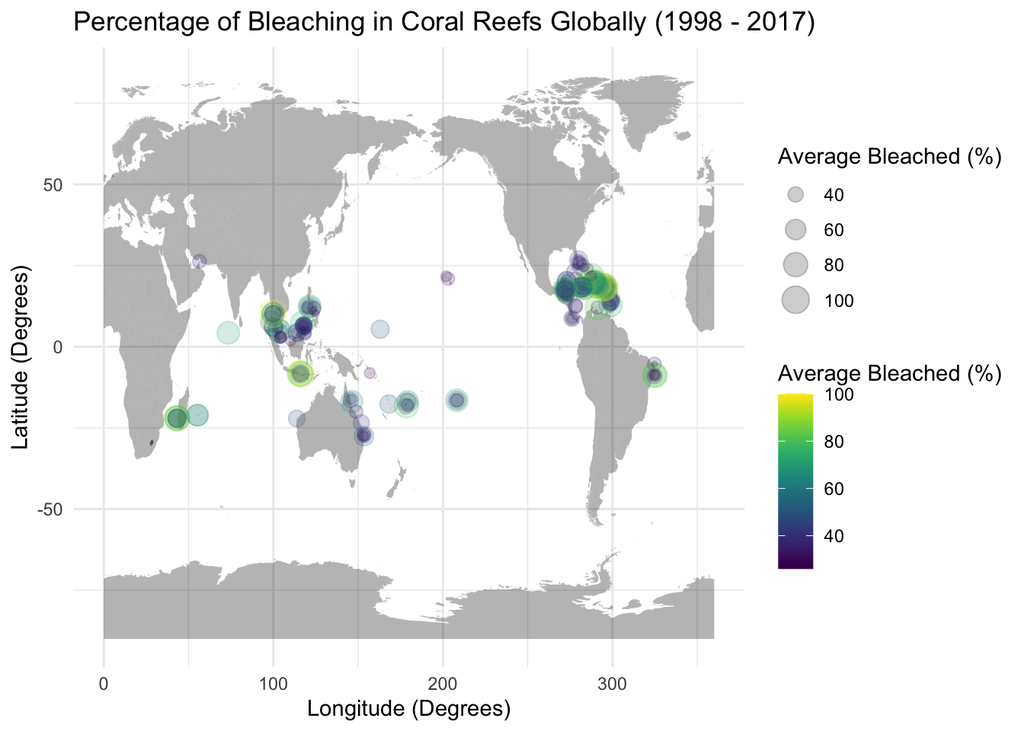

```r
# filtering events for those where an average of 25% or more has bleached, then identifying the best
reef_filtered <- reef %>% filter(Average_bleaching > 25)

# given two measurements for the same location, take the most recent
reef_filtered <- reef_filtered %>% group_by(Reef.ID) %>% slice(which.max(Year))

ggplot() +

  #overlaying world map
  geom_polygon(data = world_map,
               aes(x=long, y=lat, group = group),
               fill="black", alpha=0.3) +

  # adding coral bleaching data points with size and colour reflecting severity
  geom_point(data = reef_filtered,
             aes(x=ifelse(Longitude.Degrees < 0, Longitude.Degrees + 360,
                          Longitude.Degrees),
                 y=Latitude.Degrees,
                 size = Average_bleaching,
                 color = Average_bleaching),
             alpha=0.2) +

  scale_colour_viridis() +
  theme_minimal() +

  # adding labels
  labs(x = 'Longitude (Degrees)',
       y = 'Latitude (Degrees)',
       size = 'Average Bleached (%)',
       color = 'Average Bleached (%)',
       title = "Percentage of Bleaching in Coral Reefs Globally (1998 - 2017)")
```